# Google Data Analytics Capstone Project:

How Does a Bike-Share Navigate Speedy Success?”

Hung Ip CHAN

2022-03-28

### The scenario

In this project, I will portray as a junior data analyst in the marketing analyst team at Cyclistic, a bike-share company in Chicago. Our director of marketing believes that maximizing the number of annual memberships will lead to the company’s future success. And I am being assigned to identify the differences between casual riders and annual members when they use Cyclistic bikes so that the team can strategically influence causal riders to become members.

I will analyze the Cyclistic historical bike trip data for the past 12 months to identify trends and propose data-driven recommendations to achieve the goals.Let’s begin!!

### Step 1: Load the necessary libraries/packages

```r
if(!require(tidyverse)) install.packages("tidyverse" ,repos = "http://cran.us.r-project.org")
if(!require(dplyr)) install.packages("dplyr" ,repos = "http://cran.us.r-project.org")
if(!require(lubridate)) install.packages("lubridate" ,repos = "http://cran.us.r-project.org")
if(!require(ggplot2)) install.packages("ggplot2" ,repos = "http://cran.us.r-project.org")
if(!require(scales)) install.packages("scales" ,repos = "http://cran.us.r-project.org")

library(tidyverse)
library(dplyr)
library(lubridate)
library(ggplot2)
library(scales)
```

### Step 2: Import data

After loading the required packages for the analysis, it’s time to import the main dishes - the historical bike trip data for the last 12 months. As we got 12 csv files representing different time periods with same columns, the data files will then be merged (technically “Union” them) for easy analysis.

```r
 df_bicycle <- list.files(pattern="*.csv", full.names = T) %>%
    map_dfr(~read_csv(.))
```

### Step 3: Inspect the newly created dataframe

Let’s familiarize ourselves with the dataset by checking first/ last several rows of data.

```r
head(df_bicycle)
```

```
## # A tibble: 6 x 13
##   ride_id    rideable_type started_at ended_at start_station_n~ start_station_id
##   <chr>      <chr>         <chr>      <chr>    <chr>            <chr>
## 1 CFA86D445~ classic_bike  3/16/2021~ 3/16/20~ Humboldt Blvd &~ 15651
## 2 30D9DC612~ classic_bike  3/28/2021~ 3/28/20~ Humboldt Blvd &~ 15651
## 3 846D87A15~ classic_bike  3/11/2021~ 3/11/20~ Shields Ave & 2~ 15443
## 4 994D05AA7~ classic_bike  3/11/2021~ 3/11/20~ Winthrop Ave & ~ TA1308000021
## 5 DF7464FBE~ classic_bike  3/21/2021~ 3/21/20~ Glenwood Ave & ~ 525
## 6 CEBA8516F~ classic_bike  3/20/2021~ 3/20/20~ Glenwood Ave & ~ 525
## # ... with 7 more variables: end_station_name <chr>, end_station_id <chr>,
## #   start_lat <dbl>, start_lng <dbl>, end_lat <dbl>, end_lng <dbl>,
## #   member_casual <chr>
```

```r
tail(df_bicycle)
```

```
## # A tibble: 6 x 13
##   ride_id    rideable_type started_at ended_at start_station_n~ start_station_id
##   <chr>      <chr>         <chr>      <chr>    <chr>            <chr>
## 1 BDEB7AE26~ electric_bike 2/25/2022~ 2/25/20~ <NA>             <NA>
## 2 211BE0DC1~ electric_bike 2/23/2022~ 2/23/20~ <NA>             <NA>
## 3 D4D53E780~ electric_bike 2/4/2022 ~ 2/4/202~ <NA>             <NA>
## 4 9E85F07D2~ electric_bike 2/28/2022~ 2/28/20~ Wood St & Chica~ 637
## 5 B61B559F8~ electric_bike 2/10/2022~ 2/10/20~ <NA>             <NA>
## 6 841C70161~ electric_bike 2/21/2022~ 2/21/20~ <NA>             <NA>
## # ... with 7 more variables: end_station_name <chr>, end_station_id <chr>,
## #   start_lat <dbl>, start_lng <dbl>, end_lat <dbl>, end_lng <dbl>,
## #   member_casual <chr>
```

Besides the preview of data, the summaries of each column in our data should also be checked,for examplpe, data types, range of values, number of observations, and features of each column in our data. Now that we are familiar with the structure of our data.

```r
str(df_bicycle)
```

```
## tibble [5,667,986 x 13] (S3: tbl_df/tbl/data.frame)
##  $ ride_id           : chr [1:5667986] "CFA86D4455AA1030" "30D9DC61227D1AF3" "846D87A15682A284" "994D05AA75A168F2" ...
##  $ rideable_type     : chr [1:5667986] "classic_bike" "classic_bike" "classic_bike" "classic_bike" ...
##  $ started_at        : chr [1:5667986] "3/16/2021 8:32" "3/28/2021 1:26" "3/11/2021 21:17" "3/11/2021 13:26" ...
##  $ ended_at          : chr [1:5667986] "3/16/2021 8:36" "3/28/2021 1:36" "3/11/2021 21:33" "3/11/2021 13:55" ...
##  $ start_station_name: chr [1:5667986] "Humboldt Blvd & Armitage Ave" "Humboldt Blvd & Armitage Ave" "Shields Ave & 28th Pl" "Winthrop Ave & Lawrence Ave" ...
##  $ start_station_id  : chr [1:5667986] "15651" "15651" "15443" "TA1308000021" ...
##  $ end_station_name  : chr [1:5667986] "Stave St & Armitage Ave" "Central Park Ave & Bloomingdale Ave" "Halsted St & 35th St" "Broadway & Sheridan Rd" ...
##  $ end_station_id    : chr [1:5667986] "13266" "18017" "TA1308000043" "13323" ...
##  $ start_lat         : num [1:5667986] 41.9 41.9 41.8 42 42 ...
##  $ start_lng         : num [1:5667986] -87.7 -87.7 -87.6 -87.7 -87.7 ...
##  $ end_lat           : num [1:5667986] 41.9 41.9 41.8 42 42.1 ...
##  $ end_lng           : num [1:5667986] -87.7 -87.7 -87.6 -87.6 -87.7 ...
##  $ member_casual     : chr [1:5667986] "casual" "casual" "casual" "casual" ...
```

member_casusal column is one of the important features that will be used in the coming analysis, and nice to see it has no missing value.

```r
colSums(is.na(df_bicycle))
```

```
##            ride_id      rideable_type         started_at           ended_at
##             631226                  0                  0                  0
## start_station_name   start_station_id   end_station_name     end_station_id
##             712978             712975             761817             761817
##          start_lat          start_lng            end_lat            end_lng
##                  0                  0               4617               4617
##      member_casual
##                  0
```

### Step 4: Data Transform/ Cleaning

As we checked strucutre previously, the data type of columns “started_at” and “ended_at” is marked as character. It is difficult to calculate the time difference for the length of ride. Therefore, it is necessary to convert it into DateTime format. `mdy_hm` to match the order of formats and parse it into dates. Also, some of the end dates for rides were marked earlier than the start date. It can be presumed to be data entered incorrectly by mixing two columns. The values of these two columns will interchange if the start date is larger than the end date.

```r
df_bicycle <- df_bicycle %>%
  mutate(started_at = mdy_hm(started_at)) %>%
  mutate(ended_at = mdy_hm(ended_at)) %>%
  transform(started_at = pmin(started_at, ended_at), ended_at = pmax(started_at, ended_at))

head(df_bicycle[, c("started_at", "ended_at")])
```

```
##            started_at            ended_at
## 1 2021-03-16 08:32:00 2021-03-16 08:36:00
## 2 2021-03-28 01:26:00 2021-03-28 01:36:00
## 3 2021-03-11 21:17:00 2021-03-11 21:33:00
## 4 2021-03-11 13:26:00 2021-03-11 13:55:00
## 5 2021-03-21 09:09:00 2021-03-21 09:27:00
## 6 2021-03-20 11:08:00 2021-03-20 11:29:00
```

### Step 5: Data Organization

Now data types of the data frame are well-tuned. It’s time to organize and engineer our data to prepare for analysis. Let’s start with some calculations to get a better sense of the data. How about the length of each ride and the day of week for every observation?

```r
df_bicycle <- df_bicycle %>%
  mutate(ride_length = difftime(ended_at, started_at, units="mins")) %>%
  mutate(day_of_week = weekdays(started_at)) %>%
  mutate(month = format(started_at, "%b"))

head(df_bicycle[, c("ride_length", "day_of_week", "month")])
```

```
##   ride_length day_of_week month
## 1      4 mins     Tuesday   Mar
## 2     10 mins      Sunday   Mar
## 3     16 mins    Thursday   Mar
## 4     29 mins    Thursday   Mar
## 5     18 mins      Sunday   Mar
## 6     21 mins    Saturday   Mar
```

### Step 6: Data Analysis/ Differences spotting

Time to answer our question - How do annual members and casual riders use Cyclistic bikes differently. To answer this question, statistic data in a row-level won’t be enough.

The analysis will become more powerful when using some aggregate data. The below code chunk will be splitting the data frame based on different levels of granularities which would let us spot the differences immediately.

- Member Types
- Member Types & Day of Week
- Member Types & Month

```r
df_bicycle_gp_by_member <- df_bicycle %>%
  group_by(member_casual) %>%
  summarise(average_ride_length = mean(ride_length),
            num_of_ride = n(),
            ) %>%
  arrange(member_casual, desc(num_of_ride))

df_bicycle_gp_by_member
```

```
## # A tibble: 2 x 3
##   member_casual average_ride_length num_of_ride
##   <chr>         <drtn>                    <int>
## 1 casual        31.92155 mins           2540693
## 2 member        13.48556 mins           3127293
```

The result shows that our annual members tend to enjoy more short rides while the causal customers usually take fewer rides but longer duration. Perhaps it might be related to the use of rides. Maybe our annual members commute to work by our bikes. Let’s dip deeper into our data by grouping the data frame by member types and day of the week to verify our hypothesis.

```r
df_bicycle_gp_by_mem_month <- df_bicycle %>%
  group_by(member_casual, month) %>%
  summarise(average_ride_length = mean(ride_length),
            num_of_ride = n(),
            ) %>%
  arrange(member_casual, desc(num_of_ride))

slice_head(df_bicycle_gp_by_mem_month, n = 3)
```

```
## # A tibble: 6 x 4
## # Groups:   member_casual [2]
##   member_casual month average_ride_length num_of_ride
##   <chr>         <chr> <drtn>                    <int>
## 1 casual        Jul   32.79030 mins            442056
## 2 casual        Aug   28.78613 mins            412671
## 3 casual        Jun   37.12120 mins            370681
## 4 member        Sep   13.73588 mins            392257
## 5 member        Aug   14.10084 mins            391681
## 6 member        Jul   14.23966 mins            380354
```

It can only be concluded the popular season for our bike rental services is summer based on the top 3 highest number of rentals in each member type. It’s hard to see the complete picture through the table. Therefore, a line chart would be constructed to observe the time-series changes in the visualization section.

```r
df_bicycle_gp_by_mem_day <- df_bicycle %>%
  group_by(member_casual, day_of_week) %>%
  summarise(average_ride_length = mean(ride_length),
            num_of_ride = n()
            ) %>%
  arrange(member_casual,desc(num_of_ride))

slice_head(df_bicycle_gp_by_mem_day, n = 3)
```

```
## # A tibble: 6 x 4
## # Groups:   member_casual [2]
##   member_casual day_of_week average_ride_length num_of_ride
##   <chr>         <chr>       <drtn>                    <int>
## 1 casual        Saturday    34.54600 mins            557121
## 2 casual        Sunday      37.50055 mins            483607
## 3 casual        Friday      30.17132 mins            364903
## 4 member        Wednesday   12.65137 mins            486765
## 5 member        Tuesday     12.67949 mins            479230
## 6 member        Thursday    12.67408 mins            459171
```

Now the differences between annual members and causal customers become clearer. Casual customers are more likely to spend their weekend time on our services, whereas annual members consume our services in weekday.

### Step 7: Data Visualization

The data process and analysis are finally done and ready to tell the story behind it. The data table is boring and hard to deliver the data story to stakeholders, it’s time to create compelling visualization to tell our insight!

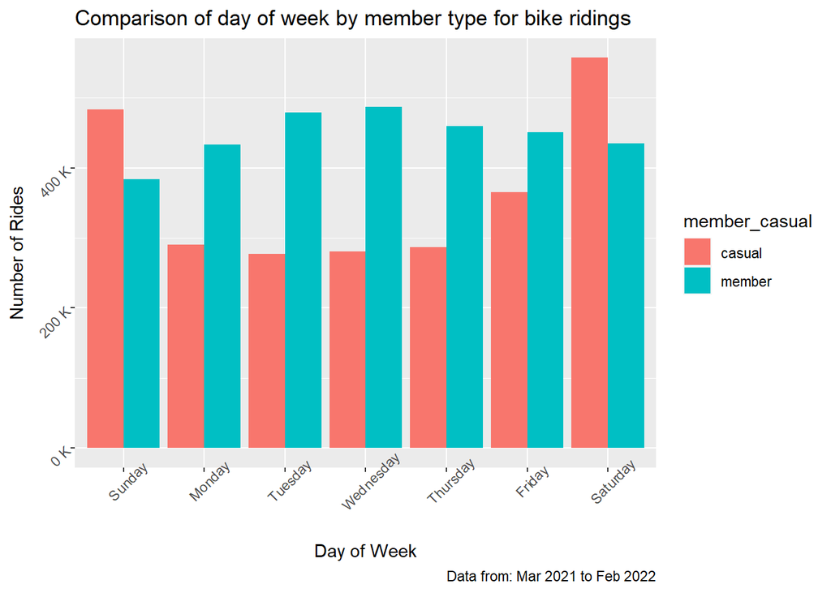

```r
Day_of_week_Order <- c("Sunday", "Monday",
    "Tuesday", "Wednesday", "Thursday", "Friday", "Saturday")

ggplot(data = df_bicycle_gp_by_mem_day) +
  geom_bar(mapping = aes(fill = member_casual, x = factor(day_of_week, levels = Day_of_week_Order), y = num_of_ride), stat="identity", position = "dodge") +
  theme(axis.text.x = element_text(angle = 45)) +
  theme(axis.text.y = element_text(angle = 45)) +
  scale_y_continuous(labels = unit_format(unit = "K", scale = 1e-3)) +
  labs(title="Comparison of day of week by member type for bike ridings",
       caption=paste0("Data from: Mar 2021 to Feb 2022"),
       x="Day of Week",
       y="Number of Rides")
```

The above plot shows that one of the main differences between casual riders and our annual members is the usage of our bikes. Annual members could be classified as commuters, whereas casual riders are leisure riders. The number of rides for casual riders skyrocketed during the weekend, while the number of rides for manual riders remained steady across the week.

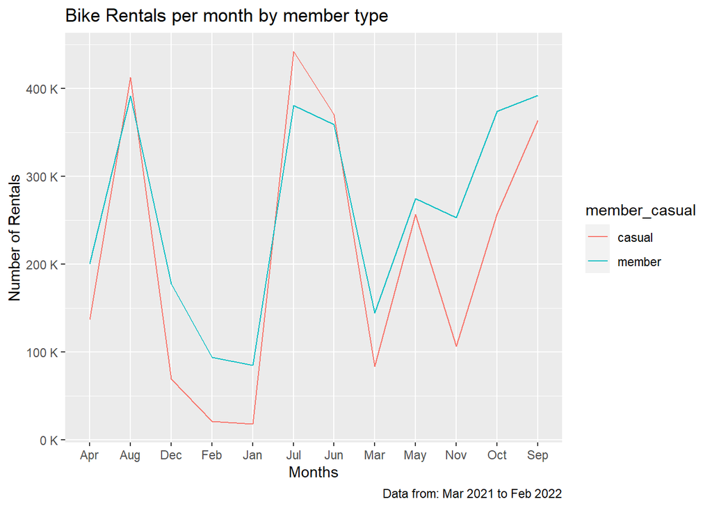

```r
ggplot(df_bicycle_gp_by_mem_month, aes(x = month, y = num_of_ride, group = member_casual)) +
  geom_line(aes(color = member_casual)) +
  labs(title="Bike Rentals per month by member type",
       caption=paste0("Data from: Mar 2021 to Feb 2022"),
       x="Months",
       y="Number of Rentals") +
  scale_y_continuous(labels = unit_format(unit = "K", scale = 1e-3))
```

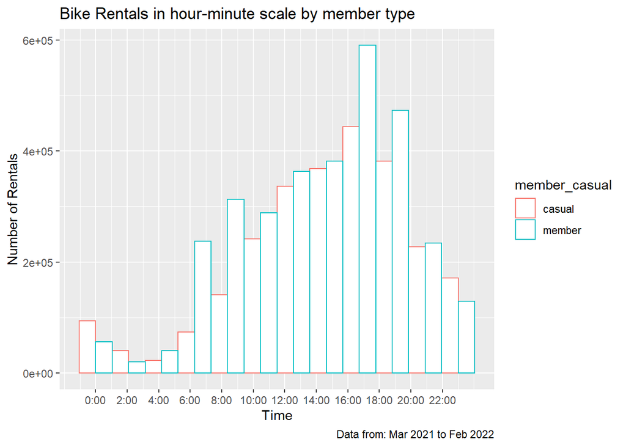

```r
ggplot(df_bicycle, aes(x = hour(started_at), color = member_casual)) +
  geom_histogram(fill="white", position="dodge", bins = 12) +
  scale_x_continuous(breaks = seq(0, 23, 2), labels = paste(seq(0, 23, 2), "00", sep = ":")) +
  labs(title="Bike Rentals in hour-minute scale by member type",
      caption=paste0("Data from: Mar 2021 to Feb 2022"),
      x="Time",
      y="Number of Rentals")
```

### Conclusion

We can conclude that the major difference between annual members and casual riders is the purpose of use. Considering that digital media has large user coverage and enormous influences in recent years, it is critical to use these advantages of digital media to maximize the number of annual memberships. For example, advertising the environmental and physical health benefits if everyone starts to take a bike to commute instead of cars. In addition, the company can then launch a promotion program to giveaway discounts/ rewards for newly registered annual members who take a rental during commuting time.